# 1US0 TYR Ring_0_0.1_10_Density

## Sample=1us0-a:39:cd1-a:39:cg-a:39:cd2

| pdb_code | central atom | ca density | parallel atom | pa density | planar atom | pl density |
| --- | --- | --- | --- | --- | --- | --- |
| 1us0 | [14.84, -3.41, 38.3] | 228.8276 | [14.02, -2.84, 37.31] | 218.9281 | [14.64, -2.45, 36.13] | 212.654 |

## Slices along x,y and z

Sliced x-wise

Sliced y-wise

Sliced z-wise

50/101

50/101

50/101

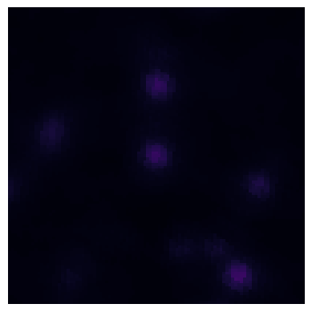

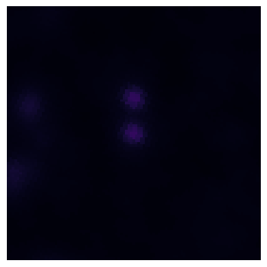

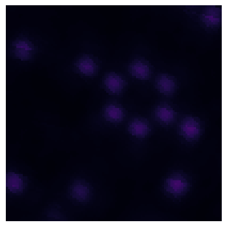

## Sample=1us0-a:48:cd1-a:48:cg-a:48:cd2

| pdb_code | central atom | ca density | parallel atom | pa density | planar atom | pl density |
| --- | --- | --- | --- | --- | --- | --- |
| 1us0 | [12.99, -9.03, 21.09] | 249.1143 | [12.39, -9.32, 22.31] | 248.4829 | [12.33, -8.31, 23.27] | 239.4885 |

## Slices along x,y and z

Sliced x-wise

Sliced y-wise

Sliced z-wise

50/101

50/101

50/101

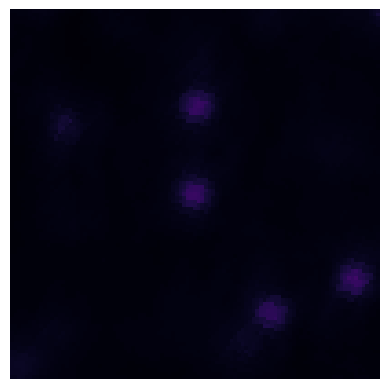

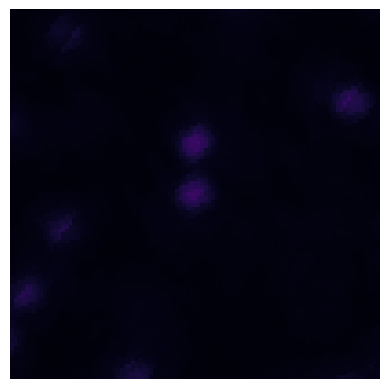

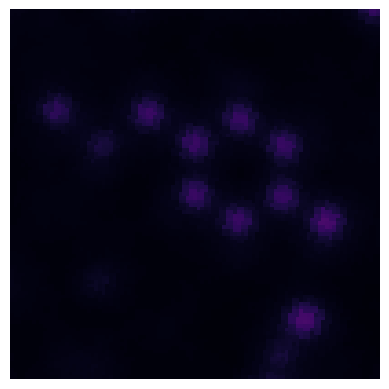

## Sample=1us0-a:82:cd1-a:82:cg-a:82:cd2

| pdb_code | central atom | ca density | parallel atom | pa density | planar atom | pl density |
| --- | --- | --- | --- | --- | --- | --- |
| 1us0 | [1.48, -9.21, 12.78] | 168.5297 | [2.42, -8.2, 12.89] | 203.0285 | [3.65, -8.6, 13.45] | 181.4336 |

## Slices along x,y and z

Sliced x-wise

Sliced y-wise

Sliced z-wise

50/101

50/101

50/101

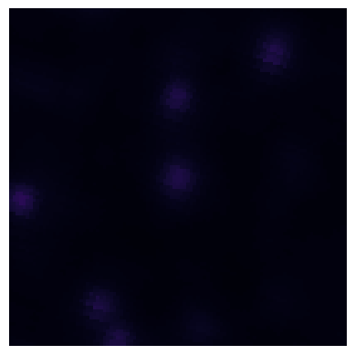

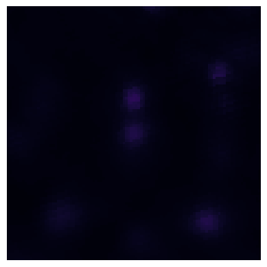

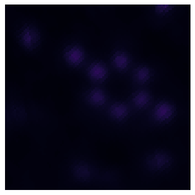

## Sample=1us0-a:103:cd1-a:103:cg-a:103:cd2

| pdb_code | central atom | ca density | parallel atom | pa density | planar atom | pl density |
| --- | --- | --- | --- | --- | --- | --- |
| 1us0 | [-4.05, -0.28, 30.93] | 178.1165 | [-3.33, 0.07, 29.79] | 195.543 | [-2.16, 0.79, 29.97] | 192.8793 |

## Slices along x,y and z

Sliced x-wise

Sliced y-wise

Sliced z-wise

50/101

50/101

50/101

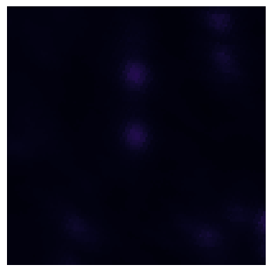

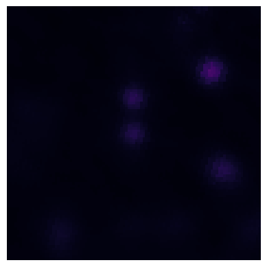

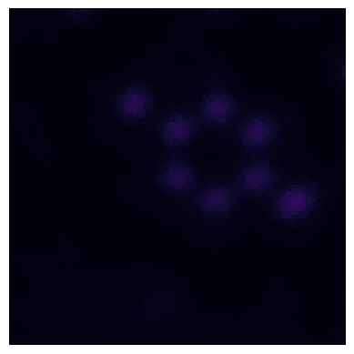

## Sample=1us0-a:107:cd1-a:107:cg-a:107:cd2

| pdb_code | central atom | ca density | parallel atom | pa density | planar atom | pl density |
| --- | --- | --- | --- | --- | --- | --- |
| 1us0 | [2.98, -2.14, 21.05] | 232.8407 | [2.34, -0.97, 20.64] | 248.7073 | [1.6, -1.03, 19.46] | 227.0822 |

## Slices along x,y and z

Sliced x-wise

Sliced y-wise

Sliced z-wise

50/101

50/101

50/101

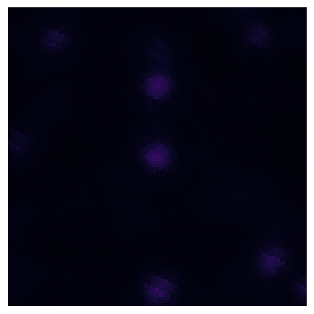

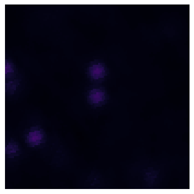

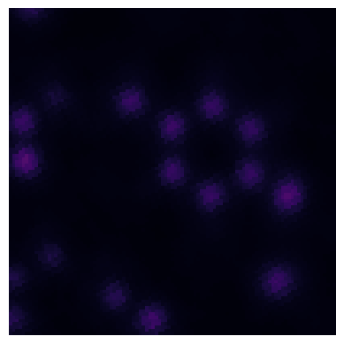

## Sample=1us0-a:177:cd1-a:177:cg-a:177:cd2

| pdb_code | central atom | ca density | parallel atom | pa density | planar atom | pl density |
| --- | --- | --- | --- | --- | --- | --- |
| 1us0 | [-2.84, 11.67, 20.07] | 184.4796 | [-2.26, 10.7, 19.24] | 193.0889 | [-3.11, 9.69, 18.77] | 183.6971 |

## Slices along x,y and z

Sliced x-wise

Sliced y-wise

Sliced z-wise

50/101

50/101

50/101

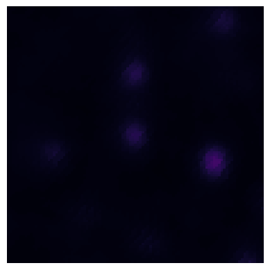

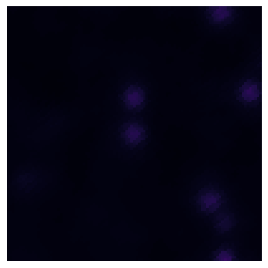

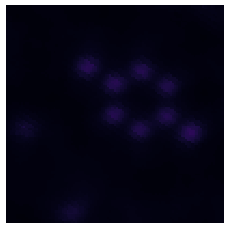

## Sample=1us0-a:189:cd1-a:189:cg-a:189:cd2

| pdb_code | central atom | ca density | parallel atom | pa density | planar atom | pl density |
| --- | --- | --- | --- | --- | --- | --- |
| 1us0 | [33.15, 2.66, 22.43] | 188.0037 | [32.21, 1.83, 21.81] | 198.2205 | [32.3, 0.47, 22.08] | 176.5354 |

## Slices along x,y and z

Sliced x-wise

Sliced y-wise

Sliced z-wise

50/101

50/101

50/101

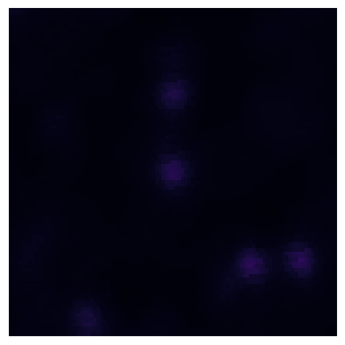

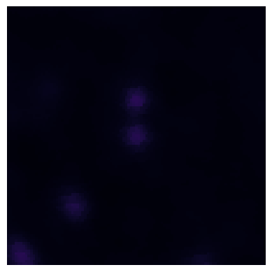

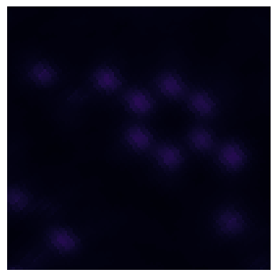

## Sample=1us0-a:198:cd1-a:198:cg-a:198:cd2

| pdb_code | central atom | ca density | parallel atom | pa density | planar atom | pl density |
| --- | --- | --- | --- | --- | --- | --- |
| 1us0 | [15.45, 17.09, 14.15] | 131.5419 | [15.77, 15.84, 14.69] | 148.5815 | [14.81, 14.84, 14.48] | 130.2614 |

## Slices along x,y and z

Sliced x-wise

Sliced y-wise

Sliced z-wise

50/101

50/101

50/101

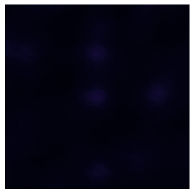

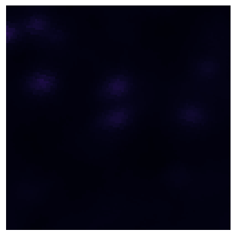

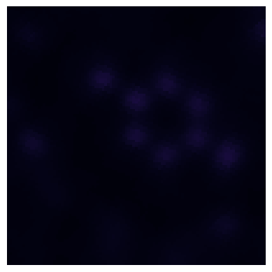

## Sample=1us0-a:209:cd1-a:209:cg-a:209:cd2

| pdb_code | central atom | ca density | parallel atom | pa density | planar atom | pl density |
| --- | --- | --- | --- | --- | --- | --- |
| 1us0 | [19.36, -1.08, 21.01] | 247.6964 | [18.29, -0.37, 21.54] | 245.1513 | [17.39, 0.19, 20.65] | 227.5703 |

## Slices along x,y and z

Sliced x-wise

Sliced y-wise

Sliced z-wise

50/101

50/101

50/101

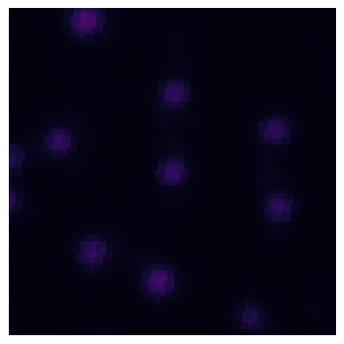

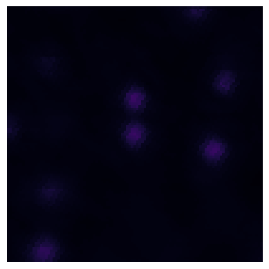

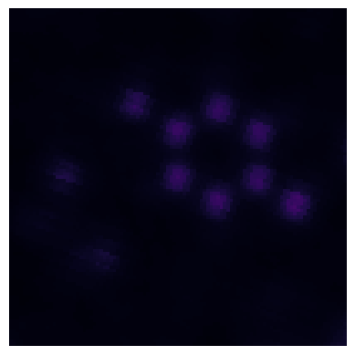

## Sample=1us0-a:291:cd1-a:291:cg-a:291:cd2

| pdb_code | central atom | ca density | parallel atom | pa density | planar atom | pl density |
| --- | --- | --- | --- | --- | --- | --- |
| 1us0 | [36.47, 7.35, 25.14] | 159.5664 | [35.3, 6.64, 25.24] | 175.3451 | [34.9, 6.23, 26.5] | 150.2094 |

## Slices along x,y and z

Sliced x-wise

Sliced y-wise

Sliced z-wise

50/101

50/101

50/101

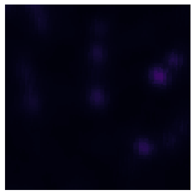

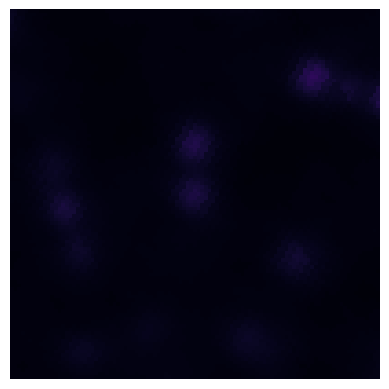

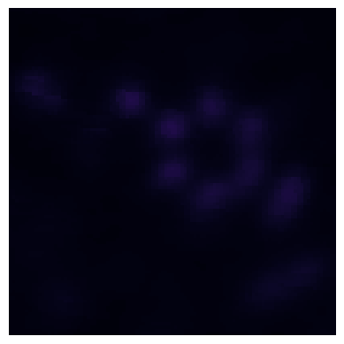

## Sample=1us0-a:309:cd1-a:309:cg-a:309:cd2

| pdb_code | central atom | ca density | parallel atom | pa density | planar atom | pl density |
| --- | --- | --- | --- | --- | --- | --- |
| 1us0 | [18.04, -1.91, 7.21] | 182.9342 | [18.3, -0.79, 6.4] | 185.8719 | [19.56, -0.21, 6.52] | 179.8897 |

## Slices along x,y and z

Sliced x-wise

Sliced y-wise

Sliced z-wise

50/101

50/101

50/101

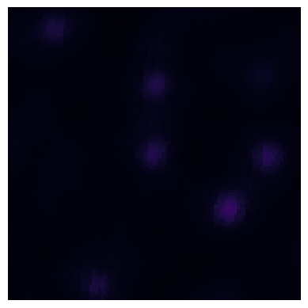

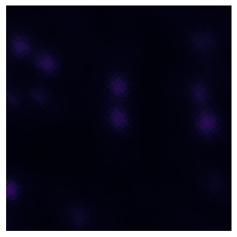

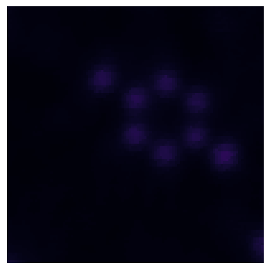

## Slices along x,y and z

Sliced x-wise

Sliced y-wise

Sliced z-wise

50/101

50/101

50/101

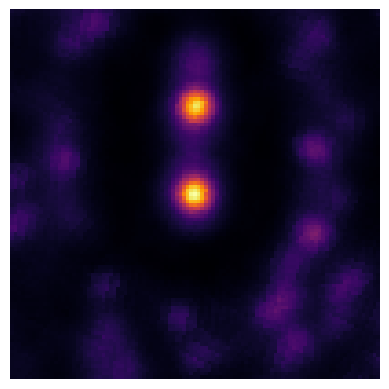

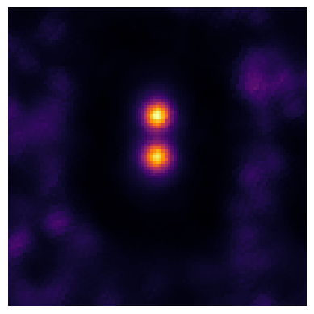

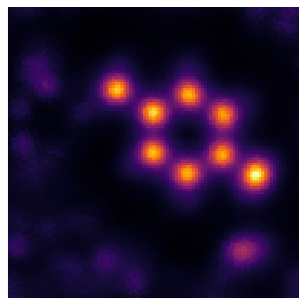

## Log-sum of all densities transformed values

## Slices along x,y and z

Sliced x-wise

Sliced y-wise

Sliced z-wise

50/101

50/101

50/101

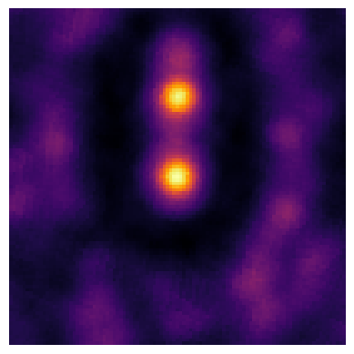

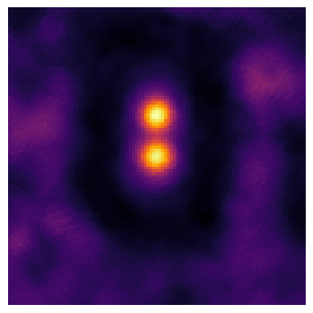

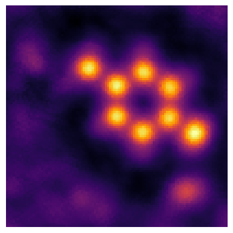